# Predicting Health Outcomes Using NHANES Data: Insights from Multivariable Analyses

Author

Bosco Bakwatanisa

Published

2024-12-06

# 1. Setup and Data Ingest

## 1.1. Loading R packages

```r
#load required R libraries
library(nhanesA)
library(forcats)
library(boot)
library(ggplot2)
library(ggpubr)
library(kableExtra)
library(janitor)
library(naniar)
library(psych)
library(patchwork)
library(gridExtra)
library(mice)
library(broom.mixed)
library(Epi)
library(vcd)
library(xfun)
library(epitools)
library(tidyverse)
theme_set(theme_light())
knitr::opts_chunk$set(comment=NA)
```

# 2. Cleaning the Data

## 2.1. Data preparation

```r
# pull in data from P_BPXO from NHANES and save it

BMX_raw <- nhanes("P_BMX")|> tibble()
saveRDS(BMX_raw, file = "data/P_BMX.rds")
demo_raw <- nhanes('P_DEMO') |> tibble()
saveRDS(demo_raw, file = "data/P_DEMO.rds")
SMQ_raw <- nhanes("P_SMQ")|> tibble()
saveRDS(SMQ_raw, file = 'data/SMQ.rds')
demo_raw <- readRDS("data/P_DEMO.rds")
BMX_raw<- readRDS("data/P_BMX.rds")
DEMO <- demo_raw%>%
  select(., SEQN,RIDSTATR,RIAGENDR,RIDAGEYR,RIDRETH3 )

BMXBMI <- BMX_raw%>%select(SEQN,BMXBMI)
analysis_tibble<- left_join(DEMO, BMXBMI, by = "SEQN")
SMQ_raw <- readRDS("data/SMQ.rds")
smoke_data <- SMQ_raw%>% select(SEQN,SMQ020)
Analysis2Data <- left_join(analysis_tibble, smoke_data, by = "SEQN")

analysis2Data <- Analysis2Data%>% filter( RIDAGEYR >=21 &  RIDAGEYR<= 79)%>%
  rename(BMI = BMXBMI, Age = RIDAGEYR, Gender =RIAGENDR, Race = RIDRETH3, Smoking = SMQ020 )%>%
  mutate(Race = factor(
    Race,
    levels = c("Mexican American","Other Hispanic","Non-Hispanic White",    "Non-Hispanic Black","Non-Hispanic Asian"),
    labels = c("Mexican","Hispanic", "White","Black", "Asian")),Gender = ifelse(Gender == "Male", 1,2))%>%filter(BMI > 0)%>%filter(Smoking %in% c('Yes', 'No')) %>%  mutate(
    Smoking = ifelse(Smoking =="Yes","Smoker","Non_Smoker"))%>% select(SEQN, Age, Gender, Race, Smoking, BMI)%>% mutate(Gender = factor(
      Gender, levels = c(1,2),labels =c("Male","Female")),Smoking = factor(Smoking,levels = c("Smoker","Non_Smoker"), labels =c("Smoker","Non_Smoker")
    ))

saveRDS(analysis2Data, file = 'data/Analyses2Data.rds')
```

```r
# Check for missing values
missing_summary <- colSums(is.na(analysis2Data))

# Imputation using `mice`
imputed_data <- mice(analysis2Data, m = 1, method = 'pmm', maxit = 5)
complete_data <- complete(imputed_data)

# Display summary
kable(head(complete_data)) %>%
  kable_styling(bootstrap_options = "striped", full_width = F)
```

| SEQN | Age | Gender | Race | Smoking | BMI |
| --- | --- | --- | --- | --- | --- |
| 109266 | 29 | Female | Asian | Non_Smoker | 37.8 |
| 109271 | 49 | Male | White | Smoker | 29.7 |
| 109273 | 36 | Male | White | Smoker | 21.9 |
| 109274 | 68 | Male | Black | Non_Smoker | 30.2 |
| 109282 | 76 | Male | White | Smoker | 26.6 |
| 109284 | 44 | Female | Mexican | Non_Smoker | 39.1 |

# 3. Codebook and Data Description

```r
variable_description <- tibble::tribble(
  ~Variable_Name, ~Role_in_Analysis,~Type, ~Original_Code,
  "SEQN",  "ID",   "Quant",   " Respondent sequence number",
  "RIDSTATR","Interview/Examination status","Binary","RIDSTATR",
  "Gender",  "Analysis Key Predictor", "Binary", "RIAGENDR",
  "Age", "Analysis key predictor and used to select Adult persons aged 21-79 years","Quant","RIDAGEYR",
  "Race/Ethnicity", "Analysis Predictor",  "X-cat", "RIDRETH3 ","BMI","Analysis Outocome", "Quant", "BMXBMI",
  "Smoking", "Analysis Predictor",  "Binary", "SMQ020")
variable_description |> kbl() |> kable_styling()
```

| Variable_Name | Role_in_Analysis | Type | Original_Code |
| --- | --- | --- | --- |
| SEQN | ID | Quant | Respondent sequence number |
| RIDSTATR | Interview/Examination status | Binary | RIDSTATR |
| Gender | Analysis Key Predictor | Binary | RIAGENDR |
| Age | Analysis key predictor and used to select Adult persons aged 21-79 years | Quant | RIDAGEYR |
| Race/Ethnicity | Analysis Predictor | X-cat | RIDRETH3 |
| BMI | Analysis Outocome | Quant | BMXBMI |
| Smoking | Analysis Predictor | Binary | SMQ020 |

### 3.1. Data Description

```r
analysis2Data <- readRDS('data/Analyses2Data.rds')
analysis2Data%>% select(Age, Gender, Race, Smoking, BMI) %>% describe() %>% kable()%>% kable_styling(bootstrap_options = "striped", full_width = F)
```

|  | vars | n | mean | sd | median | trimmed | mad | min | max | range | skew | kurtosis | se |
| --- | --- | --- | --- | --- | --- | --- | --- | --- | --- | --- | --- | --- | --- |
| Age | 1 | 7732 | 49.250647 | 15.9952871 | 50.0 | 49.321694 | 19.27380 | 21.0 | 79.0 | 58.0 | -0.0602027 | -1.1321615 | 0.1819056 |
| Gender* | 2 | 7732 | 1.517719 | 0.4997183 | 2.0 | 1.522147 | 0.00000 | 1.0 | 2.0 | 1.0 | -0.0709051 | -1.9952305 | 0.0056830 |
| Race* | 3 | 7352 | 3.194913 | 1.1874789 | 3.0 | 3.243625 | 1.48260 | 1.0 | 5.0 | 4.0 | -0.3506428 | -0.6270779 | 0.0138492 |
| Smoking* | 4 | 7732 | 1.583937 | 0.4929361 | 2.0 | 1.604914 | 0.00000 | 1.0 | 2.0 | 1.0 | -0.3405148 | -1.8842933 | 0.0056059 |
| BMI | 5 | 7732 | 30.237739 | 7.6792048 | 28.9 | 29.474232 | 6.52344 | 14.6 | 92.3 | 77.7 | 1.3473715 | 3.8124043 | 0.0873314 |

# 4. My Research Question

### **4.1. Problem Statement**

Body Mass Index (BMI) is a widely used indicator for assessing body fat based on height and weight. Gender differences in BMI may arise due to biological, hormonal, and societal factors influencing body composition, metabolism, lifestyle behaviors among others. Understanding how BMI varies with gender within a population while taking into account other confounding factors such as age, race/ethnicity, and smoking status may provide us with insights on how this association may influence the gender based health outcomes within the United States population.

### 4.2. Research Question

Is there significant relationship between Body Mass Index (BMI) and gender, while adjusting for an individual’s age, race/ethnicity, and smoking status?

# 5. Partitioning the Data

Here, I divide my analysis data into training and testing data sets in the ratio of 70% to 30%. This provides us with an opportunity to validate our model by prediction with the test dataset.

```r
# Split analysis data into training (70%) and testing (30%)
set.seed(112724)
training_data <- complete_data %>% slice_sample(prop = 0.7)
testing_data <- anti_join(complete_data, training_data, by = "SEQN")

# Confirm split
nrow(training_data)
```

```
[1] 5412
```

```r
nrow(testing_data)
```

```
[1] 2320
```

# 6. Transforming the Outcome

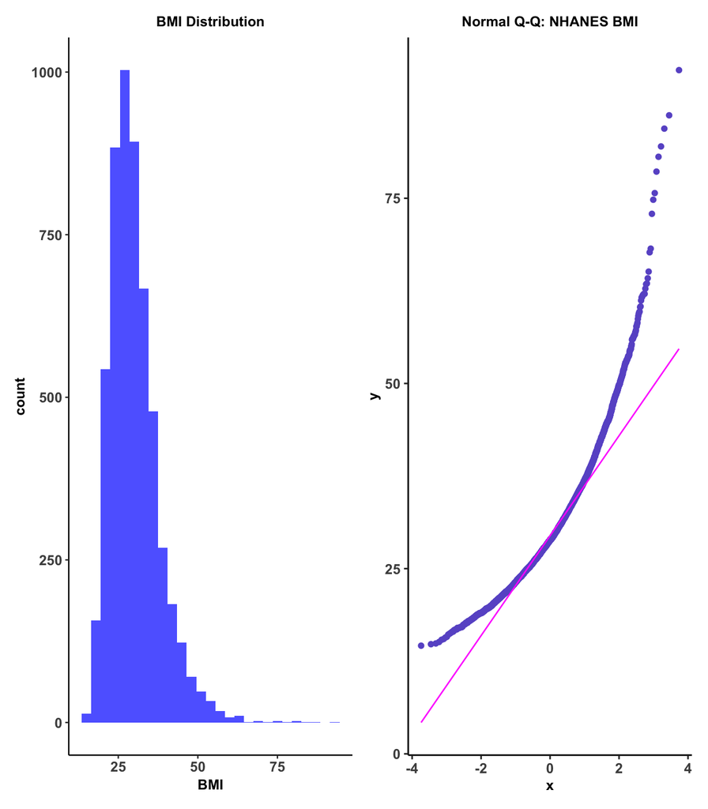

```r
# Histogram and Q-Q Plot
p1 <- ggplot(training_data, aes(x = BMI)) +
  geom_histogram(bins = 50,binwidth = 3, fill = "blue", alpha = 0.7) +
  labs(title = "BMI Distribution")+
  theme_classic(base_size = 10) +
  theme(legend.position = "left",
        axis.text = element_text(face = "bold",size = 10),
        axis.title.y = element_text(face = "bold", size = 10),
        axis.title.x = element_text(face = "bold", size = 10),
        plot.title = element_text(face = "bold", hjust = 0.5, size = 10))

p2 <- ggplot(training_data, aes(sample = BMI)) +
  geom_qq(col = "slateblue") +
  geom_qq_line(col = "magenta") +
  theme(aspect.ratio = 1) +
  labs(title = "Normal Q-Q: NHANES BMI")+
  theme_classic(base_size = 12) +
  theme(legend.position = "none",
        axis.text = element_text(face = "bold",size = 10),
        axis.title.y = element_text(face = "bold", size = 10),
        axis.title.x = element_text(face = "bold", size = 10),
        plot.title = element_text(face = "bold", hjust = 0.5, size = 10))
p1 + p2
```

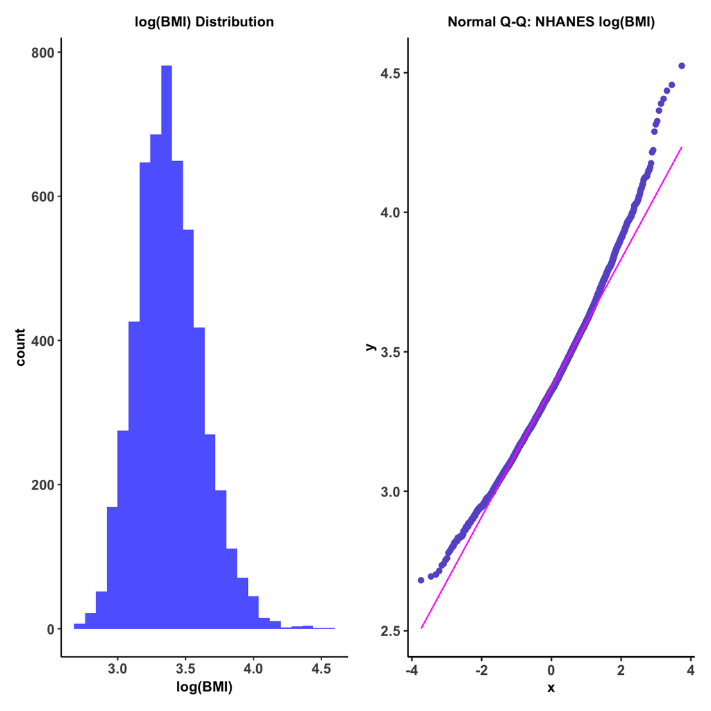

```r
# Histogram and Q-Q Plot for log transformed BMI
p1 <- ggplot(training_data, aes(x = log(BMI))) +
  geom_histogram(bin = 50,binwidth = .08, fill = "blue", alpha = 0.7) +
  labs(title = "log(BMI) Distribution")+
  theme_classic(base_size = 10) +
  theme(legend.position = "left",
        axis.text = element_text(face = "bold",size = 10),
        axis.title.y = element_text(face = "bold", size = 10),
        axis.title.x = element_text(face = "bold", size = 10),
        plot.title = element_text(face = "bold", hjust = 0.5, size = 10))

p2 <- ggplot(training_data, aes(sample = log(BMI))) +
  geom_qq(col = "slateblue") +
  geom_qq_line(col = "magenta") +
  theme(aspect.ratio = 1) +
  labs(title = "Normal Q-Q: NHANES log(BMI)")+
  theme_classic(base_size = 12) +
  theme(legend.position = "none",
        axis.text = element_text(face = "bold",size = 10),
        axis.title.y = element_text(face = "bold", size = 10),
        axis.title.x = element_text(face = "bold", size = 10),
        plot.title = element_text(face = "bold", hjust = 0.5, size = 10))
p1 + p2
```

# 7. The Big Model

Using the training data, I fitted a multivariate linear regression model as a means of assessing the association between Gender and Body mass index and other confounding variables of age, race/ethnicity, and smoking status

```r
# Big Model
big_model <- lm(BMI ~ Gender + Age + Race + Smoking, data = training_data)
tidy(big_model, conf.int = TRUE)%>% select(-statistic)%>% kable(digits = 3)
```

| term | estimate | std.error | p.value | conf.low | conf.high |
| --- | --- | --- | --- | --- | --- |
| (Intercept) | 29.587 | 0.447 | 0.000 | 28.710 | 30.464 |
| GenderFemale | 1.312 | 0.208 | 0.000 | 0.904 | 1.720 |
| Age | 0.012 | 0.006 | 0.054 | 0.000 | 0.025 |
| RaceHispanic | -1.006 | 0.418 | 0.016 | -1.825 | -0.188 |
| RaceWhite | -0.788 | 0.337 | 0.020 | -1.449 | -0.126 |
| RaceBlack | 0.810 | 0.340 | 0.017 | 0.143 | 1.476 |
| RaceAsian | -4.994 | 0.400 | 0.000 | -5.779 | -4.210 |
| SmokingNon_Smoker | 0.151 | 0.217 | 0.485 | -0.273 | 0.576 |

### 7.1. Big Model Summary Statistics

```r
tidy(big_model)%>% kable(digits = 3)%>%kable_styling(bootstrap_options = "striped", full_width = F)
```

| term | estimate | std.error | statistic | p.value |
| --- | --- | --- | --- | --- |
| (Intercept) | 29.587 | 0.447 | 66.147 | 0.000 |
| GenderFemale | 1.312 | 0.208 | 6.301 | 0.000 |
| Age | 0.012 | 0.006 | 1.925 | 0.054 |
| RaceHispanic | -1.006 | 0.418 | -2.410 | 0.016 |
| RaceWhite | -0.788 | 0.337 | -2.334 | 0.020 |
| RaceBlack | 0.810 | 0.340 | 2.381 | 0.017 |
| RaceAsian | -4.994 | 0.400 | -12.482 | 0.000 |
| SmokingNon_Smoker | 0.151 | 0.217 | 0.698 | 0.485 |

### 7.2. Model Residuals

```r
#Extracting the residuals from the model
residuals <- resid(big_model)
fitted_values <- fitted(big_model)
```

### 7.3. Diagnostic Plots

To check whether the fitted model meets the linearity assumption, normality of residuals, homoscedasticity, and influential points, I extracted the residuals and their fitted values to plot the ‘Residuals vs. Fitted Plot’, normality Q-Q plot, Scale-location plot, and the residuals vs. leverage plot as shown below.

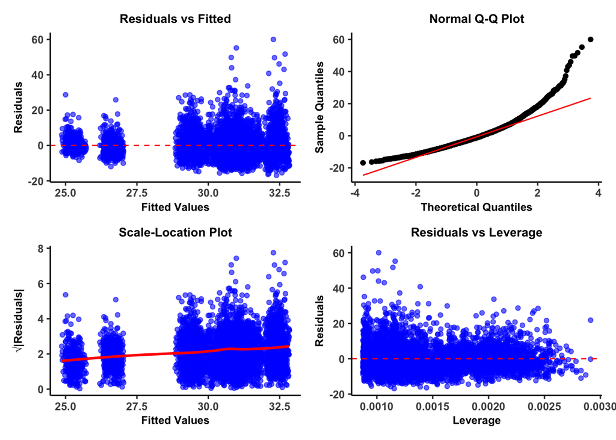

```r
# Residuals vs Fitted Plot
p1<- ggplot(data = data.frame(fitted_values, residuals), aes(x = fitted_values, y = residuals)) +
  geom_point(color = "blue", alpha = 0.6) +
  geom_hline(yintercept = 0, linetype = "dashed", color = "red") +
  labs(title = "Residuals vs Fitted",
       x = "Fitted Values",
       y = "Residuals") +
  theme_classic(base_size = 12) +
  theme(
        axis.text = element_text(face = "bold",size = 9),
        axis.title.y = element_text(face = "bold", size = 9),
        axis.title.x = element_text(face = "bold", size = 9),
        plot.title = element_text(face = "bold", hjust = 0.5, size = 10))

# Normal Q-Q Plot
p2 <- ggplot(data = data.frame(residuals), aes(sample = residuals)) +
  stat_qq() +
  stat_qq_line(color = "red") +
  labs(title = "Normal Q-Q Plot",
       x = "Theoretical Quantiles",
       y = "Sample Quantiles") +
  theme_classic(base_size = 12) +
  theme(
        axis.text = element_text(face = "bold",size = 9),
        axis.title.y = element_text(face = "bold", size = 9),
        axis.title.x = element_text(face = "bold", size = 9),
        plot.title = element_text(face = "bold", hjust = 0.5, size = 10))

# Scale-Location Plot
sqrt_abs_residuals <- sqrt(abs(residuals))
p3 <- ggplot(data = data.frame(fitted_values, sqrt_abs_residuals), aes(x = fitted_values, y = sqrt_abs_residuals)) +
  geom_point(color = "blue", alpha = 0.6) +
  geom_smooth(method = "loess", color = "red", se = FALSE) +
  labs(title = "Scale-Location Plot",
       x = "Fitted Values",
       y = "√|Residuals|") +
    theme_classic(base_size = 12) +
  theme(
        axis.text = element_text(face = "bold",size = 9),
        axis.title.y = element_text(face = "bold", size = 9),
        axis.title.x = element_text(face = "bold", size = 9),
        plot.title = element_text(face = "bold", hjust = 0.5, size = 10))

# Residuals vs Leverage Plot
leverage <- hatvalues(big_model)
p4 <- ggplot(data = data.frame(leverage, residuals), aes(x = leverage, y = residuals)) +
  geom_point(color = "blue", alpha = 0.6) +
  geom_hline(yintercept = 0, linetype = "dashed", color = "red") +
  labs(title = "Residuals vs Leverage",
       x = "Leverage",
       y = "Residuals") +
   theme_classic(base_size = 12) +
  theme(
        axis.text = element_text(face = "bold",size = 9),
        axis.title.y = element_text(face = "bold", size = 9),
        axis.title.x = element_text(face = "bold", size = 9),
        plot.title = element_text(face = "bold", hjust = 0.5, size = 10))

p1 + p2 + p3 + p4
```

From the residuals vs. Fitted plot, I observed that the residuals do not appear to be randomly scattered around the red dashed horizontal line at zero and there are clusters indicating non-linearity. The spread of residuals seemed to increase slightly for higher fitted values, suggesting heteroscedasticity. The normal Q-Q plot shows that residuals deviate from the red line, particularly in the top tail, indicating that residuals are not normally distributed, hence suggesting skewness. Additionally, from the Scale-location plot, the red trend line shows a slight upward slope, suggesting increasing variance of residuals with fitted values. This altogether points to violation of assumptions for homoscedasticity, linearity, normality of residuals.

# 8. The Smaller Model

The small model only interrogated the direct relationship between BMI and Gender without considering and confounding variables

```r
# Smaller Model
small_model <- lm(BMI ~ Gender, data = training_data)
summary(small_model)
```

```
Call:
lm(formula = BMI ~ Gender, data = training_data)

Residuals:
    Min      1Q  Median      3Q     Max
-16.163  -5.333  -1.298   3.867  61.537

Coefficients:
             Estimate Std. Error t value Pr(>|t|)
(Intercept)   29.5329     0.1525 193.625  < 2e-16 ***
GenderFemale   1.2296     0.2104   5.843 5.43e-09 ***
---
Signif. codes:  0 '***' 0.001 '**' 0.01 '*' 0.05 '.' 0.1 ' ' 1

Residual standard error: 7.731 on 5410 degrees of freedom
Multiple R-squared:  0.006271,  Adjusted R-squared:  0.006087
F-statistic: 34.14 on 1 and 5410 DF,  p-value: 5.433e-09
```

# 9. In-Sample Comparison

Here, we assess model performance between the big-model and small-model using the training data set and assess the quality of model fitting by looking at key statistical measures such as R-Squared, Adjusted R-Squared, Akaike Information criterion (AIC) and Bayesian Information Criterion (BIC) and Log-Likelihood

## 9.1. Quality of Fit

```r
# R-Squared and Adjusted R-Squared
r_squared_big <- summary(big_model)$r.squared
adj_r_squared_big <- summary(big_model)$adj.r.squared

r_squared_small <- summary(small_model)$r.squared
adj_r_squared_small <- summary(small_model)$adj.r.squared

# AIC and BIC
aic_big <- AIC(big_model)
bic_big <- BIC(big_model)

aic_small <- AIC(small_model)
bic_small <- BIC(small_model)

# Log-Likelihood
loglik_big <- logLik(big_model)
loglik_small <- logLik(small_model)

# Create a summary table
quality_of_fit <- data.frame(
  Model = c("Big Model", "Small Model"),
  R_Squared = c(r_squared_big, r_squared_small),
  Adjusted_R_Squared = c(adj_r_squared_big, adj_r_squared_small),
  AIC = c(aic_big, aic_small),
  BIC = c(bic_big, bic_small),
  Log_Likelihood = c(loglik_big, loglik_small)
)


quality_of_fit%>% kable(digits = 3)%>%kable_styling(bootstrap_options = "striped", full_width = F)
```

| Model | R_Squared | Adjusted_R_Squared | AIC | BIC | Log_Likelihood |
| --- | --- | --- | --- | --- | --- |
| Big Model | 0.060 | 0.059 | 37211.27 | 37270.64 | -18596.64 |
| Small Model | 0.006 | 0.006 | 37500.02 | 37519.81 | -18747.01 |

## 9.2. Posterior Predictive Checks

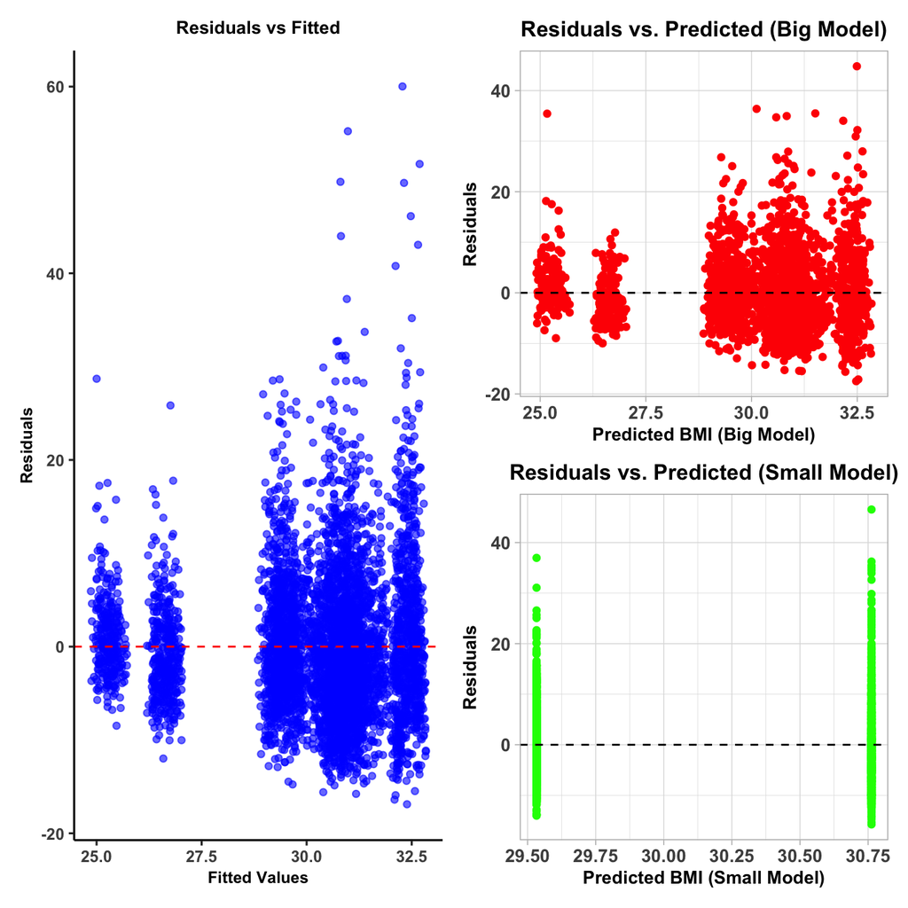

```r
# Simulate posterior predictive distribution for the Big Model
set.seed(123)
pred_big <- predict(big_model, newdata = testing_data, interval = "predict")

# Simulate posterior predictive distribution for the Small Model
pred_small <- predict(small_model, newdata = testing_data, interval = "predict")
# Combine observed and predicted data
testing_data$Pred_Big <- pred_big[, "fit"]
testing_data$Pred_Small <- pred_small[, "fit"]

# Density plot for observed vs. predicted
library(ggplot2)
p <- ggplot(testing_data) +
  geom_density(aes(x = BMI, fill = "Observed"), alpha = 0.4) +
  geom_density(aes(x = Pred_Big, fill = "Big Model Prediction"), alpha = 0.4) +
  geom_density(aes(x = Pred_Small, fill = "Small Model Prediction"), alpha = 0.4) +
  labs(title = "Posterior Predictive Check: Observed vs Predicted BMI",
       x = "BMI",
       y = "Density") +
theme(
        axis.text = element_text(face = "bold",size = 10),
        axis.title.y = element_text(face = "bold", size = 10),
        axis.title.x = element_text(face = "bold", size = 10),
        plot.title = element_text(face = "bold", hjust = 0.5, size = 12)) +
  scale_fill_manual(values = c("Observed" = "blue",
                                "Big Model Prediction" = "red",
                                "Small Model Prediction" = "green"))
# Residuals for Big and Small Models
testing_data$Residual_Big <- testing_data$BMI - testing_data$Pred_Big
testing_data$Residual_Small <- testing_data$BMI - testing_data$Pred_Small

# Residual plots
p2 <- ggplot(testing_data) +
  geom_point(aes(x = Pred_Big, y = Residual_Big), color = "red") +
  geom_hline(yintercept = 0, linetype = "dashed") +
  labs(title = "Residuals vs. Predicted (Big Model)",
       x = "Predicted BMI (Big Model)",
       y = "Residuals") +
theme(
        axis.text = element_text(face = "bold",size = 10),
        axis.title.y = element_text(face = "bold", size = 10),
        axis.title.x = element_text(face = "bold", size = 10),
        plot.title = element_text(face = "bold", hjust = 0.5, size = 12))

p3 <- ggplot(testing_data) +
  geom_point(aes(x = Pred_Small, y = Residual_Small), color = "green") +
  geom_hline(yintercept = 0, linetype = "dashed") +
  labs(title = "Residuals vs. Predicted (Small Model)",
       x = "Predicted BMI (Small Model)",
       y = "Residuals") +
 theme(
        axis.text = element_text(face = "bold",size = 10),
        axis.title.y = element_text(face = "bold", size = 10),
        axis.title.x = element_text(face = "bold", size = 10),
        plot.title = element_text(face = "bold", hjust = 0.5, size = 12))

p1+p2/p3
```

```r
# Add predictive intervals
testing_data$Lower_Big <- pred_big[, "lwr"]
testing_data$Upper_Big <- pred_big[, "upr"]
testing_data$Lower_Small <- pred_small[, "lwr"]
testing_data$Upper_Small <- pred_small[, "upr"]

# Coverage check
testing_data$Covered_Big <- with(testing_data, BMI >= Lower_Big & BMI <= Upper_Big)
testing_data$Covered_Small <- with(testing_data, BMI >= Lower_Small & BMI <= Upper_Small)

# Calculate coverage percentages
coverage_big <- mean(testing_data$Covered_Big) * 100
coverage_small <- mean(testing_data$Covered_Small) * 100
coverage_big
```

```
[1] 95.90517
```

```r
coverage_small
```

```
[1] 96.07759
```

## 9.4. Comparing the Models

```r
comparison <- data.frame(
  Model = c("Big Model", "Small Model"),
  R_squared = c(summary(big_model)$r.squared, summary(small_model)$r.squared),
  AIC = c(AIC(big_model), AIC(small_model)),
  BIC = c(BIC(big_model), BIC(small_model))
)

kable(comparison) %>%
  kable_styling(bootstrap_options = "striped", full_width = F)
```

| Model | R_squared | AIC | BIC |
| --- | --- | --- | --- |
| Big Model | 0.0599860 | 37211.27 | 37270.64 |
| Small Model | 0.0062706 | 37500.02 | 37519.81 |

# 10. Model Validation

## 10.1. Calculating Prediction Errors

[output not shown]

```r
# Calculate residuals for both models
residuals_big <- testing_data$BMI - test_predictions_big
residuals_small <- testing_data$BMI - test_predictions_small

# Mean Absolute Error (MAE)
mae_big <- mean(abs(residuals_big))
mae_small <- mean(abs(residuals_small))

# Root Mean Squared Error (RMSE)
rmse_big <- sqrt(mean(residuals_big^2))
rmse_small <- sqrt(mean(residuals_small^2))

# R-squared for predictions
sst <- sum((testing_data$BMI - mean(testing_data$BMI))^2)  # Total Sum of Squares
sse_big <- sum(residuals_big^2)  # Sum of Squared Errors for big model
sse_small <- sum(residuals_small^2)  # Sum of Squared Errors for small model

r_squared_big <- 1 - (sse_big / sst)
r_squared_small <- 1 - (sse_small / sst)

# Create a summary table
comparison_table <- data.frame(
  Model = c("Big Model", "Small Model"),
  MAE = c(mae_big, mae_small),
  RMSE = c(rmse_big, rmse_small),
  R_Squared = c(r_squared_big, r_squared_small)
)

# Print the table
print(comparison_table)
```

```
        Model      MAE     RMSE  R_Squared
1   Big Model 5.408285 7.257644 0.06331564
2 Small Model 5.632456 7.469028 0.00795793
```

## 10.2. Visualizing the Predictions

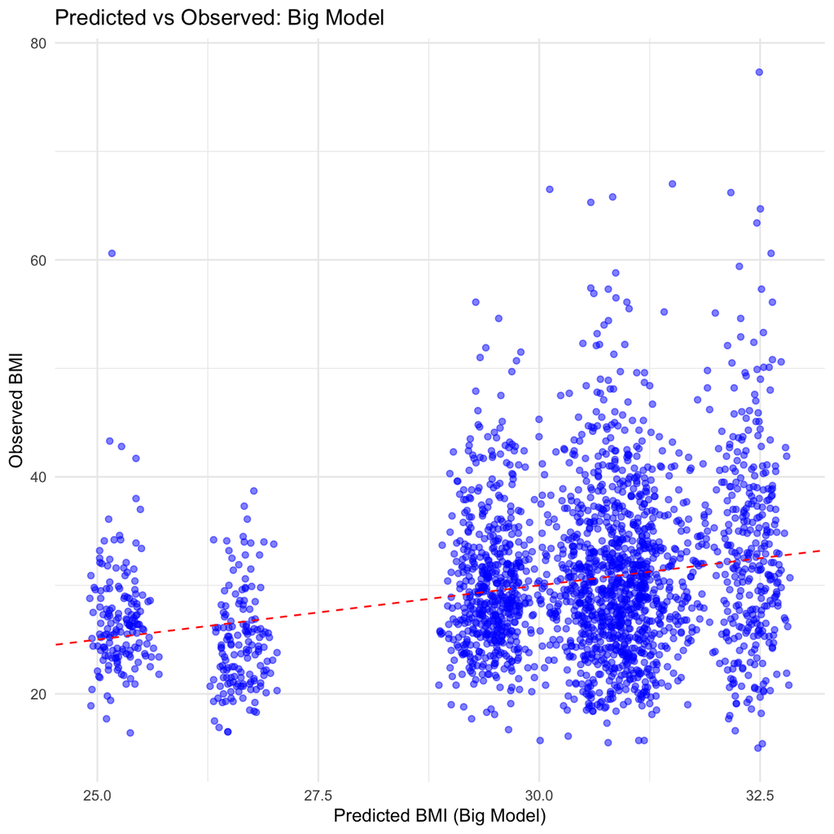

```r
library(ggplot2)

# Combine predictions and observed data
testing_data$Pred_Big <- test_predictions_big
testing_data$Pred_Small <- test_predictions_small

# Plot for Big Model
ggplot(testing_data, aes(x = Pred_Big, y = BMI)) +
  geom_point(color = "blue", alpha = 0.5) +
  geom_abline(slope = 1, intercept = 0, color = "red", linetype = "dashed") +
  labs(title = "Predicted vs Observed: Big Model",
       x = "Predicted BMI (Big Model)",
       y = "Observed BMI") +
  theme_minimal()
```

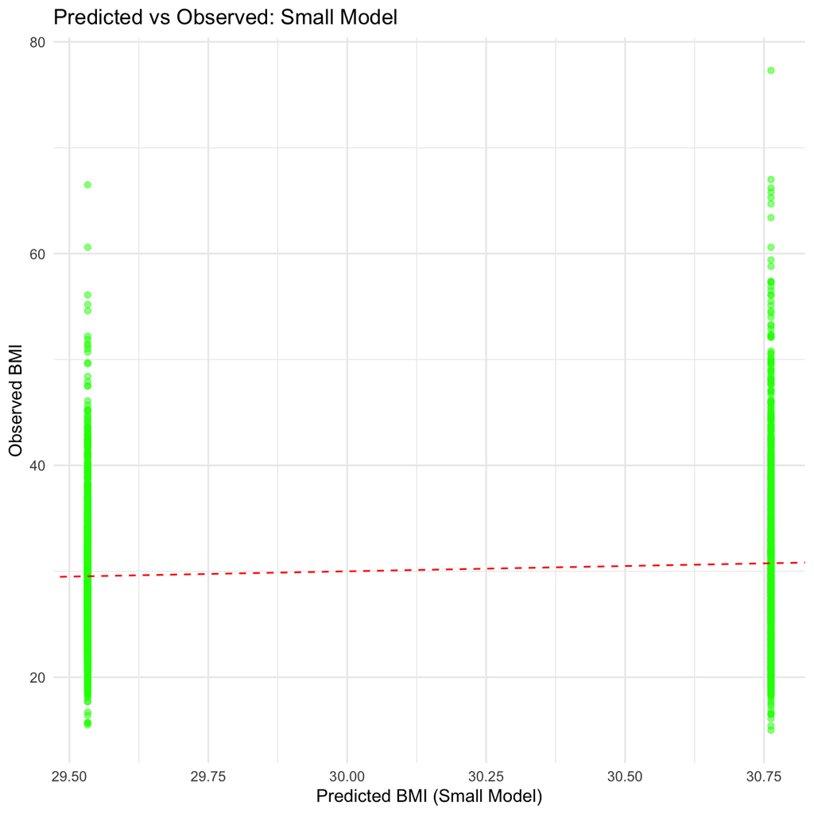

```r
# Plot for Small Model
ggplot(testing_data, aes(x = Pred_Small, y = BMI)) +
  geom_point(color = "green", alpha = 0.5) +
  geom_abline(slope = 1, intercept = 0, color = "red", linetype = "dashed") +
  labs(title = "Predicted vs Observed: Small Model",
       x = "Predicted BMI (Small Model)",
       y = "Observed BMI") +
  theme_minimal()
```

# 11. Discussion